# Aditya_Mengani_W203_Unit7_Homework

Load the data set into R workspace

```r
load("~/Downloads/unit_7_hw-master/gpa1.RData")
```

Problem 1.0 : Examine the skipped variable and argue whether or not a t-test is valid for this scenario. (3 points)

Solution : There are 141 occurences of the skipped variable population. When we plot the distribution of the variable, it shows a skewed curve as below:

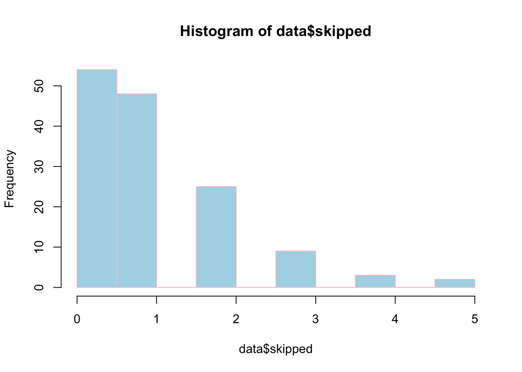

```r
hist(data$skipped, breaks = 12, col = "lightblue", border = "pink")
```

-We cannot determine with this distribution if T-test can be used. Instead, according to the assumptions of the T-test, when we do samples on the distribution, the sampling mean follows a normal distribution. -We can use this assumption on the dataset and use CLT to prove that T-test is valid for this distribution, as it attains a normal distribution for large sample n > 30. Thus a T-test can be valid in this scenario. -Another assumption for a T-test would be, each observation of variable (skipped) should be independent of other observations. With out any information provided regarding the relationship of the variables it can be assumed that ‘skipped’ is iid random variable. -Third reason would be that the population variance is not mentioned,(if given a z-test would suffice but since population variance is not provided we use t-test)

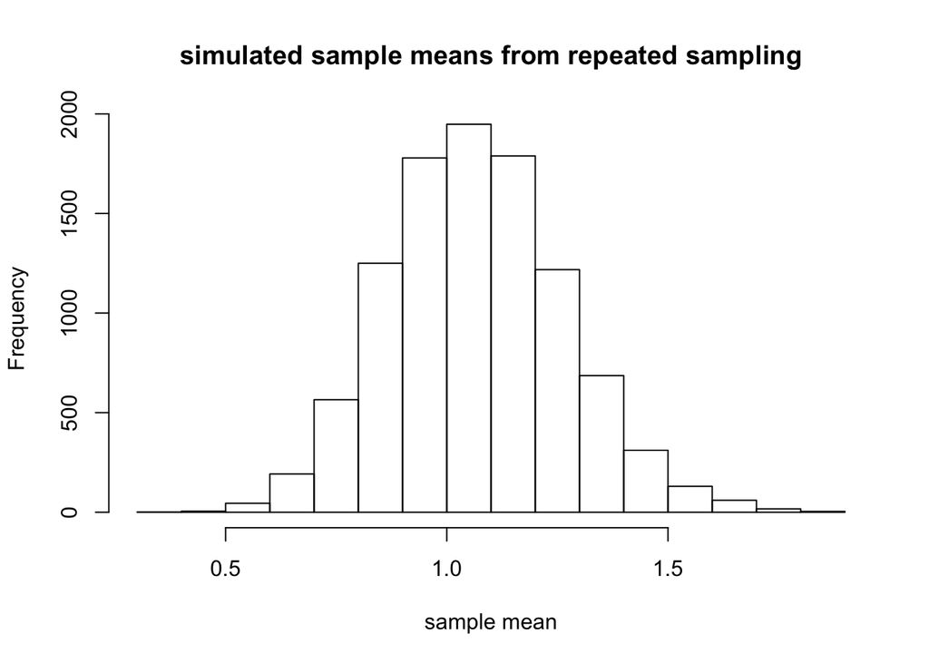

```r
skipped <- data$skipped
n3 <- 30
draws3 <- replicate(10000,mean(sample(skipped,n3,replace=T)))
hist(draws3,breaks=20,
     main = "simulated sample means from repeated sampling",
     xlab = "sample mean")
```

Problem 2.0: How would your answer to part a change if Mr. Lemmon selected dormitory rooms at random, then interviewed all occupants in the rooms he selected? (3 points)